# Get to know OCED

**Hometown**

### Where is OCED from?

[interactive chart not shown]

**School Location**

### Where did OCED go to school?

[interactive chart not shown]

**Years in Florida**

### How long have OCED members lived in FL?

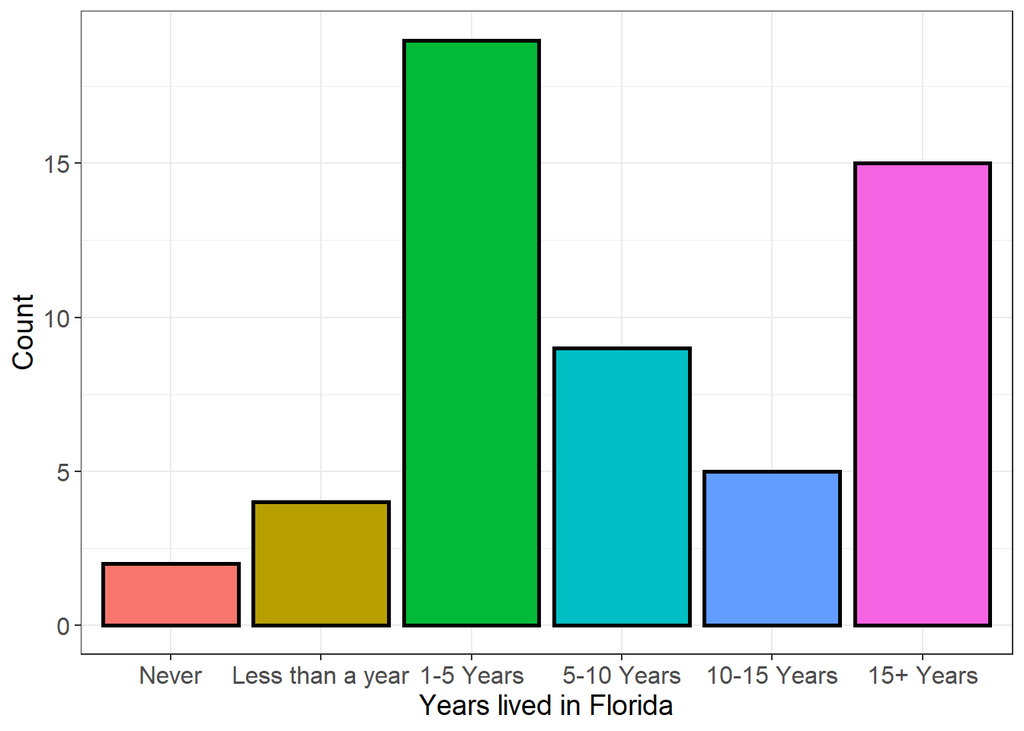

**Miami Place**

### Where in Miami is your favorite place?

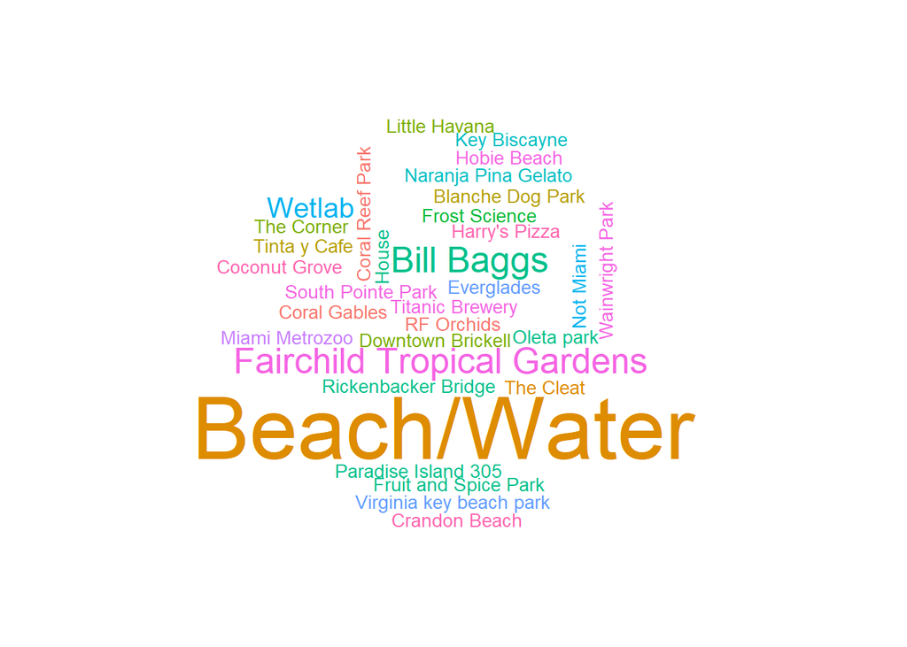

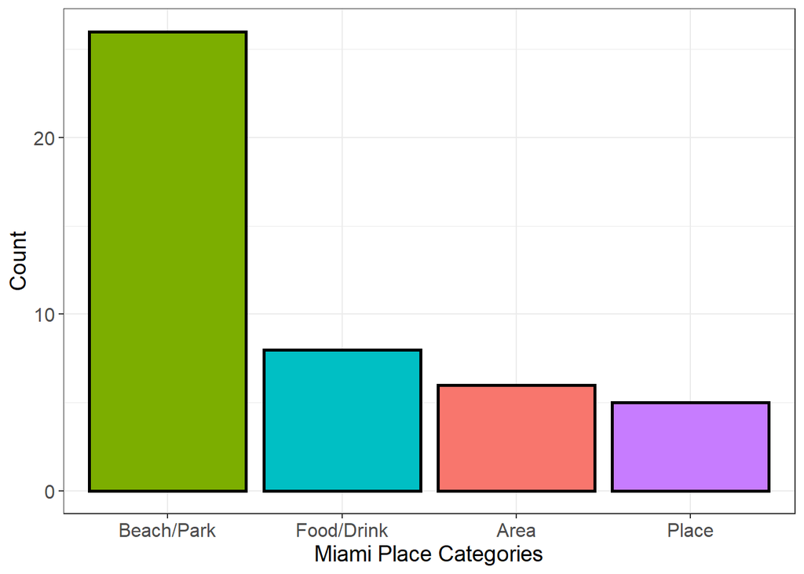

**Hobbies**

### What are OCED’s hobbies?

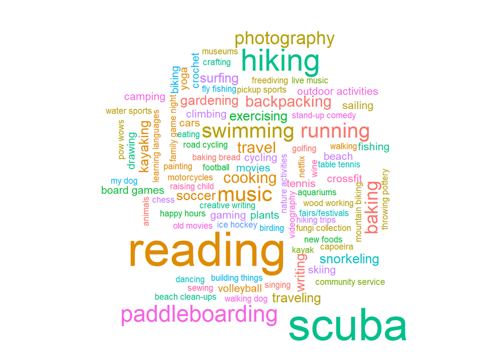

**Pets**

### What kind of pets does OCED have?

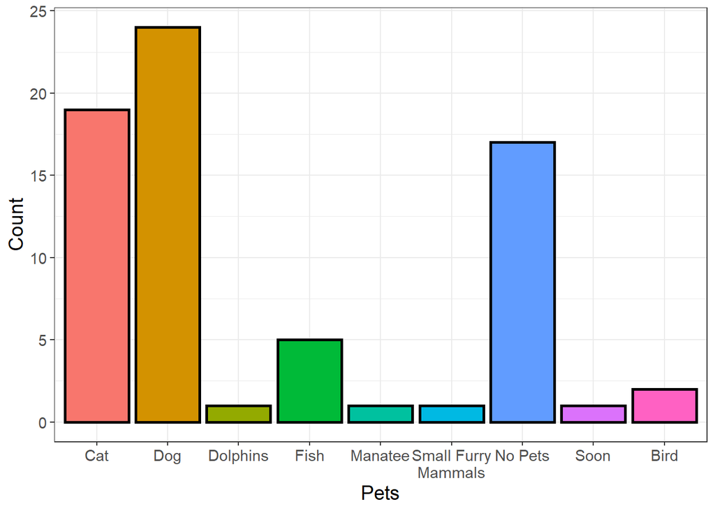

**Favorite Food**

### What are OCED’s favorite foods?

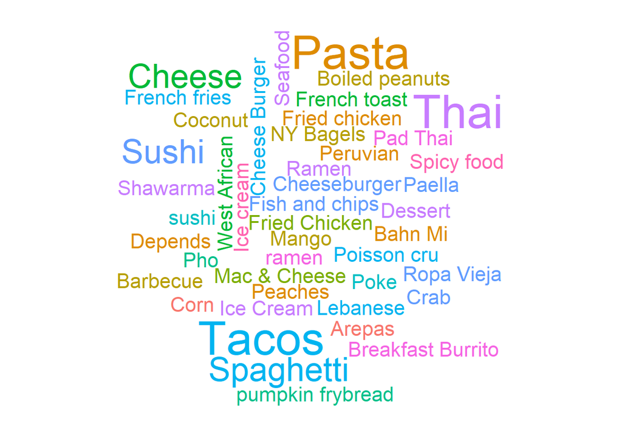

**Favorite Animal**

### What are OCED’s favorite animals?

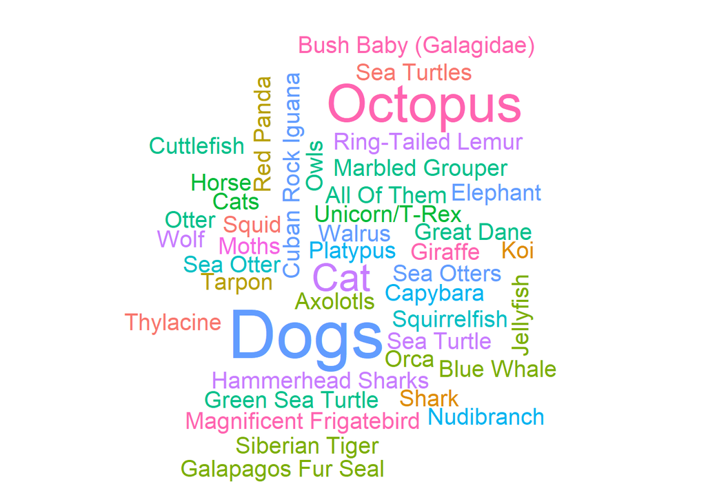

**Favorite Season**

### What is OCED’s favorite season?

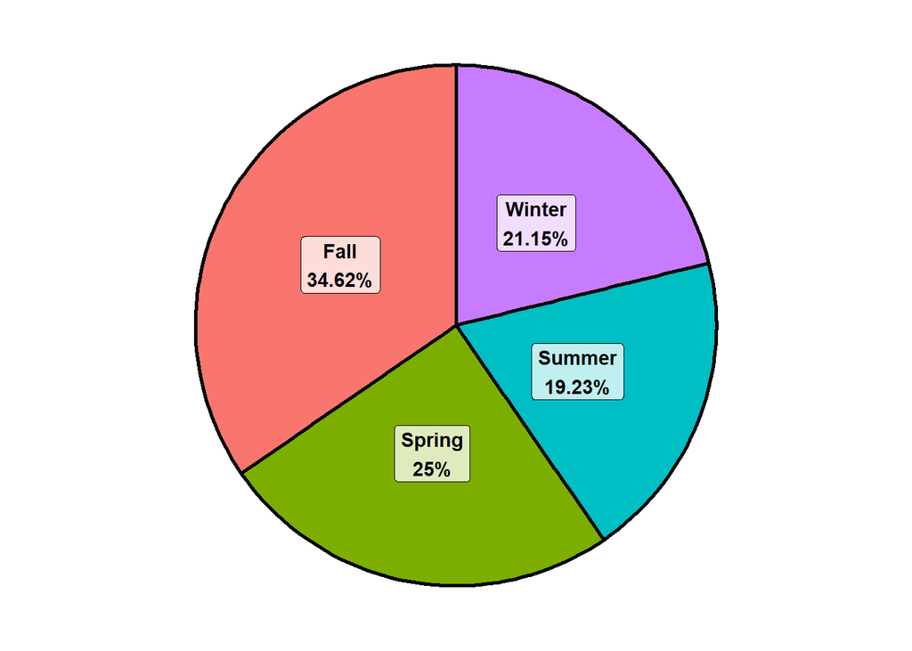

**Favorite Sport**

### What are OCED’s favorite sports?

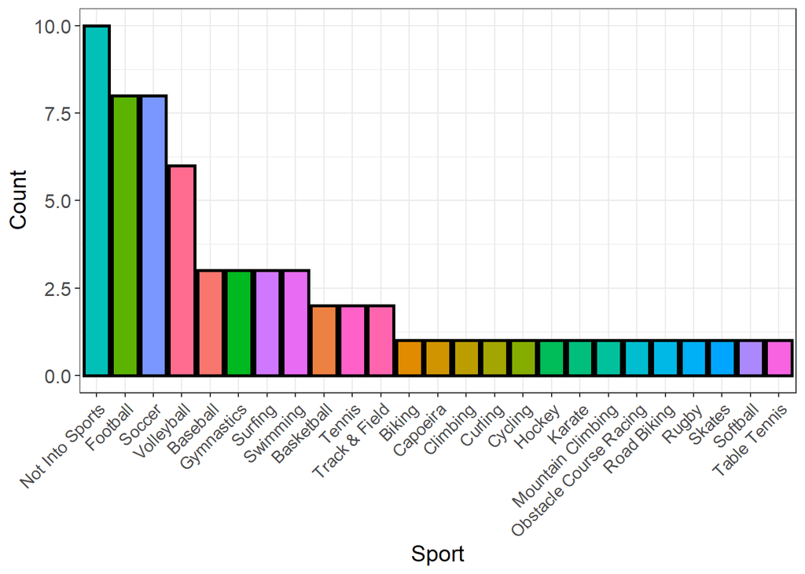

**Fun Fact**

### What are some of the fun facts about OCED?

**Previous Job/Experience:**

• Cabinet maker  
• Shaved ice truck  
• Mosquito father  
• Rock climbing instructor  
• Amateur filmmaker  
• Wrote a book series (5th grade)  
• Narrated dolphin shows  
• Been in weird bands  
• Played with orangutans  
• Snoopy mascot at local amusement park  
• Child singer at carnegie hall  
• Studied in galapagos islands  
• Worked a boy scout dive liveaboard  
• Zombie in a zombie movie (imdb page)  
• Pow wow singer when younger & karate practitioner  
• Used to rebuild car engines

**Interest/Activities:**

• Ocean acidification high school science fair  
• Theatre/bio double major  
• Held lombardi trophy  
• Madagascar for honeymoon  
• I like the smell of wet dogs.  
• Dove the gbr  
• Tropical fruit enthuisast  
• Visited 40 countries  
• Traveled to 30+ countries & 6 continents  
• Is possible a pirate queen?  
• Must have coffee (x2)  
• Learning the ukulele  
• Been to 6/7 continents (7th soon)  
• Been inside the great pyramid of giza  
• Invited to a space shuttle launch

**Skill:**

• 15-min nap  
• Natural adventure planner  
• Hold breath 3 min  
• Climbed mt. Kilimanjaro  
• Finding owls in wild  
• Make stuffed animals  
• Trained in brazilian jiu-jitsu  
• Self-published poetry book  
• Raced dirt bikes in baja, mexico  
• Play 5+ instruments

**Injury:**

• Broken all fingers  
• Numb lip after wisdom teeth extraction  
• Been struck by lightning

**Miscellaneous:**

• Love cats but allergic  
• Shares birthday with star-spangled banner, amy winehouse, & ivan pavlov